# Risk Factor Analysis

## Outcome Variable

**Outcome Variable:** haz

## Predictor Variables

**Intervention Variable:** mage

**Adjustment Set:**

- arm
- meducyrs
- feducyrs
- W_mhtcm
- W_mwtkg
- W_mbmi
- single
- delta_meducyrs
- delta_feducyrs
- delta_W_mhtcm
- delta_W_mwtkg
- delta_W_mbmi
- delta_single

## Stratifying Variables

The analysis was stratified on these variable(s):

- agecat
- studyid
- country

## Data Summary

| agecat | studyid | country | mage | n_cell | n | outcome_variable |
| --- | --- | --- | --- | --- | --- | --- |
| Birth | CMC-V-BCS-2002 | INDIA | [20-30) | 79 | 92 | haz |
| Birth | CMC-V-BCS-2002 | INDIA | <20 | 9 | 92 | haz |
| Birth | CMC-V-BCS-2002 | INDIA | >=30 | 4 | 92 | haz |
| Birth | COHORTS | GUATEMALA | [20-30) | 405 | 852 | haz |
| Birth | COHORTS | GUATEMALA | <20 | 121 | 852 | haz |
| Birth | COHORTS | GUATEMALA | >=30 | 326 | 852 | haz |
| Birth | COHORTS | INDIA | [20-30) | 3180 | 4715 | haz |
| Birth | COHORTS | INDIA | <20 | 368 | 4715 | haz |
| Birth | COHORTS | INDIA | >=30 | 1167 | 4715 | haz |
| Birth | COHORTS | PHILIPPINES | [20-30) | 1821 | 3050 | haz |
| Birth | COHORTS | PHILIPPINES | <20 | 378 | 3050 | haz |
| Birth | COHORTS | PHILIPPINES | >=30 | 851 | 3050 | haz |
| Birth | EE | PAKISTAN | [20-30) | 94 | 239 | haz |
| Birth | EE | PAKISTAN | <20 | 1 | 239 | haz |
| Birth | EE | PAKISTAN | >=30 | 144 | 239 | haz |
| Birth | GMS-Nepal | NEPAL | [20-30) | 446 | 696 | haz |
| Birth | GMS-Nepal | NEPAL | <20 | 149 | 696 | haz |
| Birth | GMS-Nepal | NEPAL | >=30 | 101 | 696 | haz |
| Birth | IRC | INDIA | [20-30) | 325 | 388 | haz |
| Birth | IRC | INDIA | <20 | 35 | 388 | haz |
| Birth | IRC | INDIA | >=30 | 28 | 388 | haz |
| Birth | JiVitA-3 | BANGLADESH | [20-30) | 10853 | 22444 | haz |
| Birth | JiVitA-3 | BANGLADESH | <20 | 9472 | 22444 | haz |
| Birth | JiVitA-3 | BANGLADESH | >=30 | 2119 | 22444 | haz |
| Birth | Keneba | GAMBIA | [20-30) | 705 | 1543 | haz |
| Birth | Keneba | GAMBIA | <20 | 238 | 1543 | haz |
| Birth | Keneba | GAMBIA | >=30 | 600 | 1543 | haz |
| Birth | MAL-ED | BANGLADESH | [20-30) | 160 | 231 | haz |
| Birth | MAL-ED | BANGLADESH | <20 | 30 | 231 | haz |
| Birth | MAL-ED | BANGLADESH | >=30 | 41 | 231 | haz |

[output cut: 183 more lines]

The following strata were considered:

- agecat: 24 months, studyid: CMC-V-BCS-2002, country: INDIA
- agecat: 24 months, studyid: COHORTS, country: GUATEMALA
- agecat: 24 months, studyid: COHORTS, country: INDIA
- agecat: 24 months, studyid: COHORTS, country: PHILIPPINES
- agecat: 24 months, studyid: EE, country: PAKISTAN
- agecat: 24 months, studyid: GMS-Nepal, country: NEPAL
- agecat: 24 months, studyid: IRC, country: INDIA
- agecat: 24 months, studyid: JiVitA-3, country: BANGLADESH
- agecat: 24 months, studyid: Keneba, country: GAMBIA
- agecat: 24 months, studyid: LCNI-5, country: MALAWI
- agecat: 24 months, studyid: MAL-ED, country: BANGLADESH
- agecat: 24 months, studyid: MAL-ED, country: BRAZIL
- agecat: 24 months, studyid: MAL-ED, country: INDIA
- agecat: 24 months, studyid: MAL-ED, country: NEPAL
- agecat: 24 months, studyid: MAL-ED, country: PERU
- agecat: 24 months, studyid: MAL-ED, country: SOUTH AFRICA
- agecat: 24 months, studyid: MAL-ED, country: TANZANIA, UNITED REPUBLIC OF
- agecat: 24 months, studyid: NIH-Birth, country: BANGLADESH
- agecat: 24 months, studyid: NIH-Crypto, country: BANGLADESH
- agecat: 24 months, studyid: PROBIT, country: BELARUS
- agecat: 24 months, studyid: PROVIDE, country: BANGLADESH
- agecat: 24 months, studyid: TanzaniaChild2, country: TANZANIA, UNITED REPUBLIC OF
- agecat: 24 months, studyid: ZVITAMBO, country: ZIMBABWE
- agecat: 6 months, studyid: CMC-V-BCS-2002, country: INDIA
- agecat: 6 months, studyid: COHORTS, country: GUATEMALA
- agecat: 6 months, studyid: COHORTS, country: INDIA
- agecat: 6 months, studyid: COHORTS, country: PHILIPPINES
- agecat: 6 months, studyid: EE, country: PAKISTAN
- agecat: 6 months, studyid: GMS-Nepal, country: NEPAL
- agecat: 6 months, studyid: Guatemala BSC, country: GUATEMALA
- agecat: 6 months, studyid: IRC, country: INDIA
- agecat: 6 months, studyid: JiVitA-3, country: BANGLADESH
- agecat: 6 months, studyid: Keneba, country: GAMBIA
- agecat: 6 months, studyid: LCNI-5, country: MALAWI
- agecat: 6 months, studyid: MAL-ED, country: BANGLADESH
- agecat: 6 months, studyid: MAL-ED, country: BRAZIL
- agecat: 6 months, studyid: MAL-ED, country: INDIA
- agecat: 6 months, studyid: MAL-ED, country: NEPAL
- agecat: 6 months, studyid: MAL-ED, country: PERU
- agecat: 6 months, studyid: MAL-ED, country: SOUTH AFRICA
- agecat: 6 months, studyid: MAL-ED, country: TANZANIA, UNITED REPUBLIC OF
- agecat: 6 months, studyid: NIH-Birth, country: BANGLADESH
- agecat: 6 months, studyid: NIH-Crypto, country: BANGLADESH
- agecat: 6 months, studyid: PROBIT, country: BELARUS
- agecat: 6 months, studyid: PROVIDE, country: BANGLADESH
- agecat: 6 months, studyid: SAS-CompFeed, country: INDIA
- agecat: 6 months, studyid: SAS-FoodSuppl, country: INDIA
- agecat: 6 months, studyid: TanzaniaChild2, country: TANZANIA, UNITED REPUBLIC OF
- agecat: 6 months, studyid: ZVITAMBO, country: ZIMBABWE
- agecat: Birth, studyid: CMC-V-BCS-2002, country: INDIA
- agecat: Birth, studyid: COHORTS, country: GUATEMALA
- agecat: Birth, studyid: COHORTS, country: INDIA
- agecat: Birth, studyid: COHORTS, country: PHILIPPINES
- agecat: Birth, studyid: EE, country: PAKISTAN
- agecat: Birth, studyid: GMS-Nepal, country: NEPAL
- agecat: Birth, studyid: IRC, country: INDIA
- agecat: Birth, studyid: JiVitA-3, country: BANGLADESH
- agecat: Birth, studyid: Keneba, country: GAMBIA
- agecat: Birth, studyid: MAL-ED, country: BANGLADESH
- agecat: Birth, studyid: MAL-ED, country: BRAZIL
- agecat: Birth, studyid: MAL-ED, country: INDIA
- agecat: Birth, studyid: MAL-ED, country: NEPAL
- agecat: Birth, studyid: MAL-ED, country: PERU
- agecat: Birth, studyid: MAL-ED, country: SOUTH AFRICA
- agecat: Birth, studyid: MAL-ED, country: TANZANIA, UNITED REPUBLIC OF
- agecat: Birth, studyid: NIH-Birth, country: BANGLADESH
- agecat: Birth, studyid: NIH-Crypto, country: BANGLADESH
- agecat: Birth, studyid: PROBIT, country: BELARUS
- agecat: Birth, studyid: PROVIDE, country: BANGLADESH
- agecat: Birth, studyid: SAS-CompFeed, country: INDIA
- agecat: Birth, studyid: ZVITAMBO, country: ZIMBABWE

### Dropped Strata

Some strata were dropped due to rare outcomes:

- agecat: Birth, studyid: CMC-V-BCS-2002, country: INDIA
- agecat: Birth, studyid: EE, country: PAKISTAN
- agecat: Birth, studyid: MAL-ED, country: INDIA
- agecat: Birth, studyid: MAL-ED, country: NEPAL
- agecat: 6 months, studyid: EE, country: PAKISTAN
- agecat: 24 months, studyid: EE, country: PAKISTAN
- agecat: 24 months, studyid: MAL-ED, country: NEPAL
- agecat: 24 months, studyid: TanzaniaChild2, country: TANZANIA, UNITED REPUBLIC OF

## Methods Detail

We’re interested in the causal parameters $E[Y_a]$ for all values of $a \in \mathcal{A}$. These parameters represent the mean outcome if, possibly contrary to fact, we intervened to set all units to have $A=a$. Under the randomization and positivity assumptions, these are identified by the statistical parameters $\psi_a=E_W[E_{Y|A,W}(Y|A=a,W)]$. In addition, we’re interested in the mean of $Y$, $E[Y]$ under no intervention (the observed mean). We will estimate these parameters by using SuperLearner to fit the relevant likelihood factors – $E_{Y|A,W}(Y|A=a,W)$ and $p(A=a|W)$, and then updating our likelihood fit using a joint TMLE.

For unadjusted analyses ($W=\{\}$), initial likelihoods were estimated using Lrnr_glm to estimate the simple $E(Y|A)$ and Lrnr_mean to estimate $p(A)$. For adjusted analyses, a small library containing Lrnr_glmnet, Lrnr_xgboost, and Lrnr_mean was used.

Having estimated these parameters, we will then use the delta method to estimate relative risks and attributable risks relative to a prespecified baseline level of $A$.

# Results Detail

## Results Plots

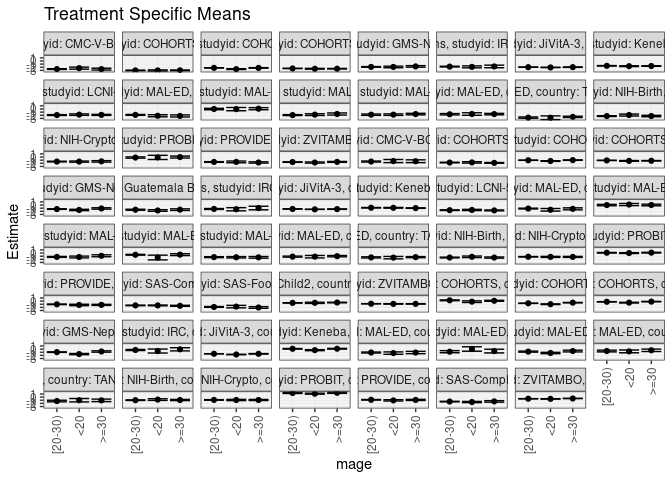

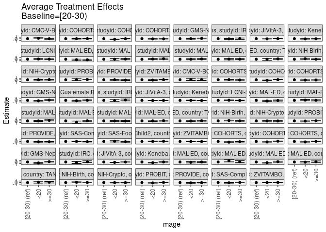

[figure not shown]

## Results Table

### Parameter: TSM

| agecat | studyid | country | intervention_level | baseline_level | estimate | ci_lower | ci_upper |
| --- | --- | --- | --- | --- | --- | --- | --- |
| Birth | COHORTS | GUATEMALA | [20-30) | NA | 0.2397609 | 0.1185176 | 0.3610042 |
| Birth | COHORTS | GUATEMALA | <20 | NA | -0.1841527 | -0.4475987 | 0.0792933 |
| Birth | COHORTS | GUATEMALA | >=30 | NA | 0.0897936 | -0.0677502 | 0.2473375 |
| Birth | COHORTS | INDIA | [20-30) | NA | -0.7077747 | -0.7485192 | -0.6670301 |
| Birth | COHORTS | INDIA | <20 | NA | -0.9923725 | -1.1093037 | -0.8754414 |
| Birth | COHORTS | INDIA | >=30 | NA | -0.5039248 | -0.5696578 | -0.4381917 |
| Birth | COHORTS | PHILIPPINES | [20-30) | NA | -0.2215875 | -0.2712752 | -0.1718998 |
| Birth | COHORTS | PHILIPPINES | <20 | NA | -0.5012901 | -0.6140757 | -0.3885046 |
| Birth | COHORTS | PHILIPPINES | >=30 | NA | -0.1739233 | -0.2477691 | -0.1000774 |
| Birth | GMS-Nepal | NEPAL | [20-30) | NA | -0.9632194 | -1.0592019 | -0.8672369 |
| Birth | GMS-Nepal | NEPAL | <20 | NA | -1.5884974 | -1.7728305 | -1.4041644 |
| Birth | GMS-Nepal | NEPAL | >=30 | NA | -0.7610962 | -0.9727616 | -0.5494308 |
| Birth | IRC | INDIA | [20-30) | NA | -0.2919487 | -0.4679414 | -0.1159559 |
| Birth | IRC | INDIA | <20 | NA | -0.6174336 | -1.2539880 | 0.0191208 |
| Birth | IRC | INDIA | >=30 | NA | -0.0682124 | -0.5706025 | 0.4341778 |
| Birth | JiVitA-3 | BANGLADESH | [20-30) | NA | -1.4909374 | -1.5167930 | -1.4650817 |
| Birth | JiVitA-3 | BANGLADESH | <20 | NA | -1.7214008 | -1.7517148 | -1.6910868 |
| Birth | JiVitA-3 | BANGLADESH | >=30 | NA | -1.5024960 | -1.5662056 | -1.4387865 |
| Birth | Keneba | GAMBIA | [20-30) | NA | 0.1001387 | 0.0060448 | 0.1942326 |
| Birth | Keneba | GAMBIA | <20 | NA | -0.3385713 | -0.5049362 | -0.1722065 |
| Birth | Keneba | GAMBIA | >=30 | NA | 0.1169841 | 0.0102280 | 0.2237402 |
| Birth | MAL-ED | BANGLADESH | [20-30) | NA | -1.0914240 | -1.2489108 | -0.9339371 |
| Birth | MAL-ED | BANGLADESH | <20 | NA | -1.2731454 | -1.6484967 | -0.8977942 |
| Birth | MAL-ED | BANGLADESH | >=30 | NA | -1.0947016 | -1.4665955 | -0.7228077 |
| Birth | MAL-ED | BRAZIL | [20-30) | NA | -0.8314634 | -1.1601853 | -0.5027415 |
| Birth | MAL-ED | BRAZIL | <20 | NA | 0.0325000 | -0.6736983 | 0.7386983 |
| Birth | MAL-ED | BRAZIL | >=30 | NA | -0.6318750 | -1.2213825 | -0.0423675 |
| Birth | MAL-ED | PERU | [20-30) | NA | -0.8086969 | -0.9682771 | -0.6491167 |
| Birth | MAL-ED | PERU | <20 | NA | -1.2408379 | -1.4582555 | -1.0234204 |
| Birth | MAL-ED | PERU | >=30 | NA | -0.6190031 | -0.9005284 | -0.3374777 |

[output cut: 159 more lines]

### Parameter: E(Y)

| agecat | studyid | country | intervention_level | baseline_level | estimate | ci_lower | ci_upper |
| --- | --- | --- | --- | --- | --- | --- | --- |
| Birth | COHORTS | GUATEMALA | NA | NA | 0.1297300 | 0.0458017 | 0.2136584 |
| Birth | COHORTS | INDIA | NA | NA | -0.6779343 | -0.7109987 | -0.6448698 |
| Birth | COHORTS | PHILIPPINES | NA | NA | -0.2490492 | -0.2880580 | -0.2100404 |
| Birth | GMS-Nepal | NEPAL | NA | NA | -1.0851580 | -1.1651811 | -1.0051350 |
| Birth | IRC | INDIA | NA | NA | -0.3080412 | -0.4687931 | -0.1472894 |
| Birth | JiVitA-3 | BANGLADESH | NA | NA | -1.5894137 | -1.6086318 | -1.5701955 |
| Birth | Keneba | GAMBIA | NA | NA | 0.0308036 | -0.0328378 | 0.0944451 |
| Birth | MAL-ED | BANGLADESH | NA | NA | -1.1180952 | -1.2525408 | -0.9836496 |
| Birth | MAL-ED | BRAZIL | NA | NA | -0.6760000 | -0.9521457 | -0.3998543 |
| Birth | MAL-ED | PERU | NA | NA | -0.8827897 | -1.0001058 | -0.7654736 |
| Birth | MAL-ED | SOUTH AFRICA | NA | NA | -0.6317073 | -0.8249555 | -0.4384591 |
| Birth | MAL-ED | TANZANIA, UNITED REPUBLIC OF | NA | NA | -1.1556000 | -1.3655361 | -0.9456639 |
| Birth | NIH-Birth | BANGLADESH | NA | NA | -0.9312706 | -1.0202524 | -0.8422889 |
| Birth | NIH-Crypto | BANGLADESH | NA | NA | -0.9094945 | -0.9809370 | -0.8380521 |
| Birth | PROBIT | BELARUS | NA | NA | 1.3114417 | 1.1524752 | 1.4704082 |
| Birth | PROVIDE | BANGLADESH | NA | NA | -0.8851020 | -0.9601332 | -0.8100709 |
| Birth | SAS-CompFeed | INDIA | NA | NA | -1.4314217 | -1.5099245 | -1.3529189 |
| Birth | ZVITAMBO | ZIMBABWE | NA | NA | -0.4999118 | -0.5204765 | -0.4793472 |
| 6 months | CMC-V-BCS-2002 | INDIA | NA | NA | -1.4234508 | -1.5645974 | -1.2823042 |
| 6 months | COHORTS | GUATEMALA | NA | NA | -1.8157336 | -1.8837688 | -1.7476985 |
| 6 months | COHORTS | INDIA | NA | NA | -1.0441293 | -1.0769738 | -1.0112848 |
| 6 months | COHORTS | PHILIPPINES | NA | NA | -1.1405724 | -1.1824954 | -1.0986493 |
| 6 months | GMS-Nepal | NEPAL | NA | NA | -1.3508392 | -1.4290633 | -1.2726152 |
| 6 months | Guatemala BSC | GUATEMALA | NA | NA | -1.5617391 | -1.6780690 | -1.4454093 |
| 6 months | IRC | INDIA | NA | NA | -1.2344062 | -1.3658524 | -1.1029600 |
| 6 months | JiVitA-3 | BANGLADESH | NA | NA | -1.3135466 | -1.3366721 | -1.2904210 |
| 6 months | Keneba | GAMBIA | NA | NA | -0.9040346 | -0.9513522 | -0.8567171 |
| 6 months | LCNI-5 | MALAWI | NA | NA | -1.6498804 | -1.7271669 | -1.5725940 |
| 6 months | MAL-ED | BANGLADESH | NA | NA | -1.2049931 | -1.3222136 | -1.0877726 |
| 6 months | MAL-ED | BRAZIL | NA | NA | 0.0475758 | -0.0963508 | 0.1915023 |
| 6 months | MAL-ED | INDIA | NA | NA | -1.2016239 | -1.3201698 | -1.0830780 |
| 6 months | MAL-ED | NEPAL | NA | NA | -0.5615819 | -0.6741832 | -0.4489807 |
| 6 months | MAL-ED | PERU | NA | NA | -1.3236661 | -1.4316775 | -1.2156546 |
| 6 months | MAL-ED | SOUTH AFRICA | NA | NA | -1.0633202 | -1.1909180 | -0.9357224 |
| 6 months | MAL-ED | TANZANIA, UNITED REPUBLIC OF | NA | NA | -1.3687449 | -1.4907629 | -1.2467270 |
| 6 months | NIH-Birth | BANGLADESH | NA | NA | -1.4062134 | -1.4951703 | -1.3172565 |
| 6 months | NIH-Crypto | BANGLADESH | NA | NA | -1.1986783 | -1.2700937 | -1.1272630 |
| 6 months | PROBIT | BELARUS | NA | NA | 0.0980074 | 0.0062724 | 0.1897424 |
| 6 months | PROVIDE | BANGLADESH | NA | NA | -1.0916915 | -1.1661176 | -1.0172654 |
| 6 months | SAS-CompFeed | INDIA | NA | NA | -1.4018563 | -1.4810585 | -1.3226541 |
| 6 months | SAS-FoodSuppl | INDIA | NA | NA | -1.8986842 | -2.0118892 | -1.7854792 |
| 6 months | TanzaniaChild2 | TANZANIA, UNITED REPUBLIC OF | NA | NA | -0.5410317 | -0.5901099 | -0.4919536 |
| 6 months | ZVITAMBO | ZIMBABWE | NA | NA | -0.8672235 | -0.8928135 | -0.8416336 |
| 24 months | CMC-V-BCS-2002 | INDIA | NA | NA | -2.5588679 | -2.6583730 | -2.4593629 |
| 24 months | COHORTS | GUATEMALA | NA | NA | -2.9905921 | -3.0548289 | -2.9263553 |
| 24 months | COHORTS | INDIA | NA | NA | -2.2182259 | -2.2576094 | -2.1788424 |
| 24 months | COHORTS | PHILIPPINES | NA | NA | -2.4141145 | -2.4590818 | -2.3691473 |
| 24 months | GMS-Nepal | NEPAL | NA | NA | -1.8874180 | -1.9728588 | -1.8019773 |
| 24 months | IRC | INDIA | NA | NA | -1.7987775 | -1.8923914 | -1.7051636 |
| 24 months | JiVitA-3 | BANGLADESH | NA | NA | -2.0137151 | -2.0414318 | -1.9859984 |
| 24 months | Keneba | GAMBIA | NA | NA | -1.5798251 | -1.6298520 | -1.5297981 |
| 24 months | LCNI-5 | MALAWI | NA | NA | -1.8966105 | -1.9881282 | -1.8050928 |
| 24 months | MAL-ED | BANGLADESH | NA | NA | -1.9783962 | -2.1050210 | -1.8517715 |
| 24 months | MAL-ED | BRAZIL | NA | NA | 0.0061144 | -0.1625850 | 0.1748138 |
| 24 months | MAL-ED | INDIA | NA | NA | -1.8901556 | -2.0155338 | -1.7647773 |
| 24 months | MAL-ED | PERU | NA | NA | -1.7524710 | -1.8736426 | -1.6312994 |
| 24 months | MAL-ED | SOUTH AFRICA | NA | NA | -1.6450595 | -1.7797240 | -1.5103950 |
| 24 months | MAL-ED | TANZANIA, UNITED REPUBLIC OF | NA | NA | -2.6455607 | -2.7807256 | -2.5103959 |
| 24 months | NIH-Birth | BANGLADESH | NA | NA | -2.2200371 | -2.3231580 | -2.1169161 |
| 24 months | NIH-Crypto | BANGLADESH | NA | NA | -1.4412646 | -1.5249156 | -1.3576135 |
| 24 months | PROBIT | BELARUS | NA | NA | -0.1442891 | -0.4253755 | 0.1367972 |
| 24 months | PROVIDE | BANGLADESH | NA | NA | -1.6024221 | -1.6857420 | -1.5191023 |
| 24 months | ZVITAMBO | ZIMBABWE | NA | NA | -1.6052656 | -1.6623196 | -1.5482116 |

### Parameter: ATE

| agecat | studyid | country | intervention_level | baseline_level | estimate | ci_lower | ci_upper |
| --- | --- | --- | --- | --- | --- | --- | --- |
| Birth | COHORTS | GUATEMALA | [20-30) | [20-30) | 0.0000000 | 0.0000000 | 0.0000000 |
| Birth | COHORTS | GUATEMALA | <20 | [20-30) | -0.4239136 | -0.7139367 | -0.1338905 |
| Birth | COHORTS | GUATEMALA | >=30 | [20-30) | -0.1499673 | -0.3487525 | 0.0488179 |
| Birth | COHORTS | INDIA | [20-30) | [20-30) | 0.0000000 | 0.0000000 | 0.0000000 |
| Birth | COHORTS | INDIA | <20 | [20-30) | -0.2845979 | -0.4083391 | -0.1608566 |
| Birth | COHORTS | INDIA | >=30 | [20-30) | 0.2038499 | 0.1269955 | 0.2807043 |
| Birth | COHORTS | PHILIPPINES | [20-30) | [20-30) | 0.0000000 | 0.0000000 | 0.0000000 |
| Birth | COHORTS | PHILIPPINES | <20 | [20-30) | -0.2797026 | -0.4024242 | -0.1569811 |
| Birth | COHORTS | PHILIPPINES | >=30 | [20-30) | 0.0476643 | -0.0404681 | 0.1357967 |
| Birth | GMS-Nepal | NEPAL | [20-30) | [20-30) | 0.0000000 | 0.0000000 | 0.0000000 |
| Birth | GMS-Nepal | NEPAL | <20 | [20-30) | -0.6252780 | -0.8323638 | -0.4181923 |
| Birth | GMS-Nepal | NEPAL | >=30 | [20-30) | 0.2021232 | -0.0301091 | 0.4343555 |
| Birth | IRC | INDIA | [20-30) | [20-30) | 0.0000000 | 0.0000000 | 0.0000000 |
| Birth | IRC | INDIA | <20 | [20-30) | -0.3254849 | -0.9868154 | 0.3358455 |
| Birth | IRC | INDIA | >=30 | [20-30) | 0.2237363 | -0.3086052 | 0.7560778 |
| Birth | JiVitA-3 | BANGLADESH | [20-30) | [20-30) | 0.0000000 | 0.0000000 | 0.0000000 |
| Birth | JiVitA-3 | BANGLADESH | <20 | [20-30) | -0.2304634 | -0.2680025 | -0.1929243 |
| Birth | JiVitA-3 | BANGLADESH | >=30 | [20-30) | -0.0115586 | -0.0779141 | 0.0547968 |
| Birth | Keneba | GAMBIA | [20-30) | [20-30) | 0.0000000 | 0.0000000 | 0.0000000 |
| Birth | Keneba | GAMBIA | <20 | [20-30) | -0.4387101 | -0.6295062 | -0.2479139 |
| Birth | Keneba | GAMBIA | >=30 | [20-30) | 0.0168454 | -0.1243183 | 0.1580091 |
| Birth | MAL-ED | BANGLADESH | [20-30) | [20-30) | 0.0000000 | 0.0000000 | 0.0000000 |
| Birth | MAL-ED | BANGLADESH | <20 | [20-30) | -0.1817215 | -0.5883926 | 0.2249497 |
| Birth | MAL-ED | BANGLADESH | >=30 | [20-30) | -0.0032776 | -0.4080064 | 0.4014511 |
| Birth | MAL-ED | BRAZIL | [20-30) | [20-30) | 0.0000000 | 0.0000000 | 0.0000000 |
| Birth | MAL-ED | BRAZIL | <20 | [20-30) | 0.8639634 | 0.0850064 | 1.6429205 |
| Birth | MAL-ED | BRAZIL | >=30 | [20-30) | 0.1995884 | -0.4753761 | 0.8745529 |
| Birth | MAL-ED | PERU | [20-30) | [20-30) | 0.0000000 | 0.0000000 | 0.0000000 |
| Birth | MAL-ED | PERU | <20 | [20-30) | -0.4321410 | -0.7037986 | -0.1604834 |
| Birth | MAL-ED | PERU | >=30 | [20-30) | 0.1896939 | -0.1337289 | 0.5131166 |

[output cut: 159 more lines]

### Parameter: PAR

| agecat | studyid | country | intervention_level | baseline_level | estimate | ci_lower | ci_upper |
| --- | --- | --- | --- | --- | --- | --- | --- |
| Birth | COHORTS | GUATEMALA | [20-30) | NA | -0.1100309 | -0.2027470 | -0.0173148 |
| Birth | COHORTS | INDIA | [20-30) | NA | 0.0298404 | 0.0065220 | 0.0531588 |
| Birth | COHORTS | PHILIPPINES | [20-30) | NA | -0.0274617 | -0.0599432 | 0.0050199 |
| Birth | GMS-Nepal | NEPAL | [20-30) | NA | -0.1219386 | -0.1845326 | -0.0593447 |
| Birth | IRC | INDIA | [20-30) | NA | -0.0160926 | -0.0890670 | 0.0568819 |
| Birth | JiVitA-3 | BANGLADESH | [20-30) | NA | -0.0984763 | -0.1162404 | -0.0807121 |
| Birth | Keneba | GAMBIA | [20-30) | NA | -0.0693351 | -0.1400231 | 0.0013529 |
| Birth | MAL-ED | BANGLADESH | [20-30) | NA | -0.0266713 | -0.1194408 | 0.0660983 |
| Birth | MAL-ED | BRAZIL | [20-30) | NA | 0.1554634 | -0.0636144 | 0.3745412 |
| Birth | MAL-ED | PERU | [20-30) | NA | -0.0740928 | -0.1983448 | 0.0501593 |
| Birth | MAL-ED | SOUTH AFRICA | [20-30) | NA | -0.0185349 | -0.1981704 | 0.1611005 |
| Birth | MAL-ED | TANZANIA, UNITED REPUBLIC OF | [20-30) | NA | 0.0957889 | -0.0895533 | 0.2811310 |
| Birth | NIH-Birth | BANGLADESH | [20-30) | NA | 0.0423022 | -0.0184115 | 0.1030159 |
| Birth | NIH-Crypto | BANGLADESH | [20-30) | NA | -0.0118003 | -0.0642042 | 0.0406035 |
| Birth | PROBIT | BELARUS | [20-30) | NA | -0.0050750 | -0.0241224 | 0.0139724 |
| Birth | PROVIDE | BANGLADESH | [20-30) | NA | -0.0293913 | -0.0799970 | 0.0212145 |
| Birth | SAS-CompFeed | INDIA | [20-30) | NA | -0.0119554 | -0.0469911 | 0.0230804 |
| Birth | ZVITAMBO | ZIMBABWE | [20-30) | NA | 0.0096367 | -0.0059903 | 0.0252636 |
| 6 months | CMC-V-BCS-2002 | INDIA | [20-30) | NA | 0.0247533 | -0.0476169 | 0.0971235 |
| 6 months | COHORTS | GUATEMALA | [20-30) | NA | -0.0535396 | -0.1303145 | 0.0232352 |
| 6 months | COHORTS | INDIA | [20-30) | NA | -0.0089785 | -0.0311893 | 0.0132323 |
| 6 months | COHORTS | PHILIPPINES | [20-30) | NA | -0.0591648 | -0.0933510 | -0.0249787 |
| 6 months | GMS-Nepal | NEPAL | [20-30) | NA | -0.0569869 | -0.1171528 | 0.0031789 |
| 6 months | Guatemala BSC | GUATEMALA | [20-30) | NA | -0.0671658 | -0.1578372 | 0.0235056 |
| 6 months | IRC | INDIA | [20-30) | NA | 0.0109209 | -0.0458029 | 0.0676448 |
| 6 months | JiVitA-3 | BANGLADESH | [20-30) | NA | -0.0604106 | -0.0797327 | -0.0410884 |
| 6 months | Keneba | GAMBIA | [20-30) | NA | -0.0417986 | -0.0911105 | 0.0075133 |
| 6 months | LCNI-5 | MALAWI | [20-30) | NA | -0.0098190 | -0.0806467 | 0.0610087 |
| 6 months | MAL-ED | BANGLADESH | [20-30) | NA | -0.0819649 | -0.1682916 | 0.0043618 |
| 6 months | MAL-ED | BRAZIL | [20-30) | NA | 0.0571490 | -0.0724060 | 0.1867040 |
| 6 months | MAL-ED | INDIA | [20-30) | NA | 0.0272312 | -0.0367760 | 0.0912384 |
| 6 months | MAL-ED | NEPAL | [20-30) | NA | -0.0089693 | -0.0756683 | 0.0577297 |
| 6 months | MAL-ED | PERU | [20-30) | NA | -0.0267264 | -0.1397761 | 0.0863234 |
| 6 months | MAL-ED | SOUTH AFRICA | [20-30) | NA | 0.0743447 | -0.0658989 | 0.2145883 |
| 6 months | MAL-ED | TANZANIA, UNITED REPUBLIC OF | [20-30) | NA | 0.0245564 | -0.0931235 | 0.1422364 |
| 6 months | NIH-Birth | BANGLADESH | [20-30) | NA | 0.0232667 | -0.0375955 | 0.0841288 |
| 6 months | NIH-Crypto | BANGLADESH | [20-30) | NA | -0.0171646 | -0.0706948 | 0.0363655 |
| 6 months | PROBIT | BELARUS | [20-30) | NA | -0.0001490 | -0.0132534 | 0.0129554 |
| 6 months | PROVIDE | BANGLADESH | [20-30) | NA | -0.0591904 | -0.1086639 | -0.0097169 |
| 6 months | SAS-CompFeed | INDIA | [20-30) | NA | -0.0187442 | -0.0384333 | 0.0009448 |
| 6 months | SAS-FoodSuppl | INDIA | [20-30) | NA | -0.0226340 | -0.1011272 | 0.0558593 |
| 6 months | TanzaniaChild2 | TANZANIA, UNITED REPUBLIC OF | [20-30) | NA | 0.0342219 | -0.0016982 | 0.0701420 |
| 6 months | ZVITAMBO | ZIMBABWE | [20-30) | NA | -0.0160917 | -0.0357184 | 0.0035350 |
| 24 months | CMC-V-BCS-2002 | INDIA | [20-30) | NA | 0.0169128 | -0.0330503 | 0.0668759 |
| 24 months | COHORTS | GUATEMALA | [20-30) | NA | 0.0224023 | -0.0471855 | 0.0919901 |
| 24 months | COHORTS | INDIA | [20-30) | NA | -0.0252938 | -0.0537310 | 0.0031434 |
| 24 months | COHORTS | PHILIPPINES | [20-30) | NA | -0.0353327 | -0.0728811 | 0.0022158 |
| 24 months | GMS-Nepal | NEPAL | [20-30) | NA | 0.0063874 | -0.0595205 | 0.0722953 |
| 24 months | IRC | INDIA | [20-30) | NA | -0.0045762 | -0.0444442 | 0.0352917 |
| 24 months | JiVitA-3 | BANGLADESH | [20-30) | NA | -0.0437448 | -0.0683675 | -0.0191221 |
| 24 months | Keneba | GAMBIA | [20-30) | NA | -0.0397548 | -0.0921620 | 0.0126525 |
| 24 months | LCNI-5 | MALAWI | [20-30) | NA | 0.0409041 | -0.0475235 | 0.1293317 |
| 24 months | MAL-ED | BANGLADESH | [20-30) | NA | -0.0993447 | -0.1847772 | -0.0139122 |
| 24 months | MAL-ED | BRAZIL | [20-30) | NA | 0.0145223 | -0.1302026 | 0.1592472 |
| 24 months | MAL-ED | INDIA | [20-30) | NA | 0.0520351 | -0.0110350 | 0.1151051 |
| 24 months | MAL-ED | PERU | [20-30) | NA | 0.0605034 | -0.0802454 | 0.2012521 |
| 24 months | MAL-ED | SOUTH AFRICA | [20-30) | NA | 0.0350633 | -0.1257969 | 0.1959235 |
| 24 months | MAL-ED | TANZANIA, UNITED REPUBLIC OF | [20-30) | NA | 0.1023596 | -0.0247706 | 0.2294898 |
| 24 months | NIH-Birth | BANGLADESH | [20-30) | NA | 0.0373045 | -0.0303872 | 0.1049961 |
| 24 months | NIH-Crypto | BANGLADESH | [20-30) | NA | 0.0090631 | -0.0513138 | 0.0694401 |
| 24 months | PROBIT | BELARUS | [20-30) | NA | 0.0215933 | -0.1462600 | 0.1894466 |
| 24 months | PROVIDE | BANGLADESH | [20-30) | NA | -0.0277561 | -0.0808919 | 0.0253796 |
| 24 months | ZVITAMBO | ZIMBABWE | [20-30) | NA | -0.0038636 | -0.0465374 | 0.0388102 |